# 19200154_Advanced R_Final Project

Aniket Guha Roy-19200164

8/14/2020

##Question1 Import the dataset exo_data.csv as a tibble. Columns 1, 16, 17, 18, 25 should be characters. Columns 2, 14 should be factors. Column 15 should be integers. The remaining columns should be doubles. Note: the ﬁle metadata.txt contains useful information about this dataset. Also, you may consult https://en.wikipedia.org/wiki/Exoplanet

```r
rm(list = ls())
exo =  as_tibble(read.csv(file.choose()))
head(exo)
```

```
## # A tibble: 6 x 25
##   id     flag    mass radius period    axis     ecc   per   lon   asc  incl
##   <chr> <int>   <dbl>  <dbl>  <dbl>   <dbl>   <dbl> <dbl> <dbl> <dbl> <dbl>
## 1 KOI-~     0  0.0014  0.054  0.177 0.00480 NA         NA    NA    NA  72
## 2 Kepl~     0 NA       0.14   4.19  0.039   NA         NA    NA    NA  89.4
## 3 KOI-~     0 NA       0.071  6.36  0.052   NA         NA    NA    NA  88.2
## 4 Kepl~     0  0.25    0.84  19.2   0.143    0.0626    NA    NA    NA  87.1
## 5 Kepl~     0  0.17    0.82  39.0   0.229    0.0684    NA    NA    NA  87.2
## 6 Kepl~     0  0.022   0.147  1.59  0.0271  NA         NA    NA    NA  NA
## # ... with 14 more variables: temp <dbl>, age <dbl>, meth <chr>, year <int>,
## #   recency <chr>, r_asc <chr>, decl <chr>, dist <dbl>, host_mass <dbl>,
## #   host_rad <dbl>, host_met <dbl>, host_temp <dbl>, host_age <dbl>,
## #   lists <chr>
```

```r
class(exo)
```

```
## [1] "tbl_df"     "tbl"        "data.frame"
```

```r
exo = exo %>%
  mutate_at(vars(flag,meth ), funs(factor))%>%
  mutate_at(vars(id,recency,r_asc,decl,lists), funs(as.character)) %>%
    mutate_at(vars(mass,radius,period,axis,ecc,per,lon,asc,incl,
                 temp,age,dist,host_mass,host_rad,host_met,host_temp,host_age), funs(as.double))
```

##Question 2 Exclude the exoplanets with an unknown method of discovery

```r
exo = exo %>%
  filter(meth!="")%>%
  droplevels()
levels(exo$meth)
```

```
## [1] "imaging"      "microlensing" "RV"           "timing"       "transit"
```

##Question 3 Create a graphic which illustrates the relationship between the log-distances from the Sun and the methods of discovery.

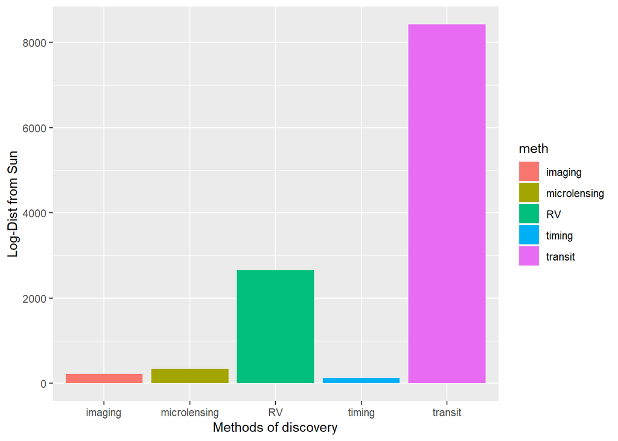

```r
ggplot(exo, aes(x = meth,y=log(dist),fill = meth))+
geom_histogram(stat = "identity") +
  ylab("Log-Dist from Sun") + xlab('Methods of discovery')
```

```r
  ggtitle("Log-Distances from sun")
```

```
## $title
## [1] "Log-Distances from sun"
##
## attr(,"class")
## [1] "labels"
```

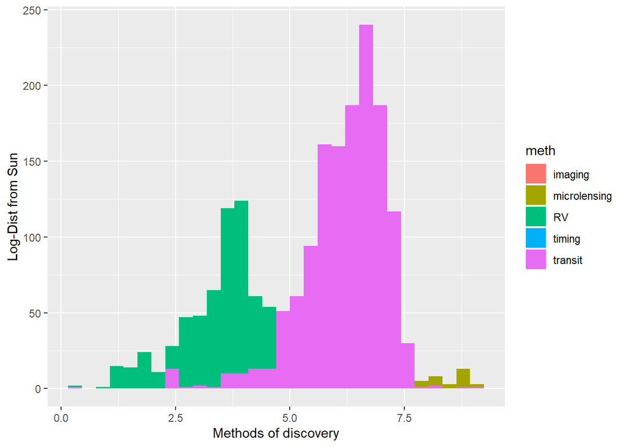

```r
ggplot(exo, aes(x=log(dist), fill = meth)) +
  geom_histogram(position="identity")  +
  ylab("Log-Dist from Sun") + xlab('Methods of discovery')
```

```r
ggtitle("Log-Distances from sun")
```

```
## $title
## [1] "Log-Distances from sun"
##
## attr(,"class")
## [1] "labels"
```

##Question 4 Create scatterplots of the log-mass versus log-distances, separating by methods of discovery. Hovering with the cursor highlights the point and displays its name, and, if you click, the exoplanet’s page on the Open Exoplanet Catalogue will be opened. (paste the id after http://www.openexoplanetcatalogue.com/planet/ ).

```r
exo$onclick = sprintf("window.open(\"%s%s\")",
                        "http://www.openexoplanetcatalogue.com/planet/",
                       exo$id)
gg_point = ggplot(data = exo,aes(x=log(dist),y=log(mass))) +
  geom_point_interactive(aes(data_id = id,tooltip = id,onclick = onclick,color = meth)) +
  ylab("Log-Mass") + xlab("Log-Dist from Sun")+
  labs(title="Scatterplots of log-mass vs. log-distances")
ggiraph(ggobj = gg_point)
```

[interactive chart not shown]

```r
##or

gg_point1 = ggplot(data = exo,aes(x=log(dist),y=log(mass))) +
  geom_point_interactive(aes(data_id = id,tooltip = id,onclick = onclick,color = meth)) +
  labs(title="Scatterplots of log-mass vs. log-distances") + theme_minimal() + facet_wrap(~meth)
ggiraph(ggobj = gg_point1)
```

[interactive chart not shown]

##Question 5 Rename the radius into jupiter_radius,and create a new column called earth_radius which is 11.2 times the Jupiter radius.

```r
exo = exo %>%
  rename(jupiter_radius = radius)%>%
  mutate(earth_radius = 11.2 * jupiter_radius)
```

##Question 6 Focus only on the rows where log-earth radius and log-period have no missing values, and perform kmeans with four clusters on these two columns.

```r
exo_kmeans = exo %>%
  filter(!is.na(period))%>%
  filter(!is.na(earth_radius))%>%
  mutate(earth_radius = log(earth_radius),
         period = log(period))
kmeans_data = exo_kmeans%>%
  select(earth_radius,period)

kmeans_data
```

```
## # A tibble: 2,732 x 2
##    earth_radius period
##           <dbl>  <dbl>
##  1       -0.503 -1.73
##  2        0.450  1.43
##  3       -0.229  1.85
##  4        2.24   2.96
##  5        2.22   3.66
##  6        0.499  0.466
##  7        0.766  2.91
##  8        2.63   1.22
##  9        0.656  1.21
## 10        1.05   1.75
## # ... with 2,722 more rows
```

```r
km = kmeans(kmeans_data,4)
table(km$cluster)
```

```
##
##    1    2    3    4
##  416 1133  798  385
```

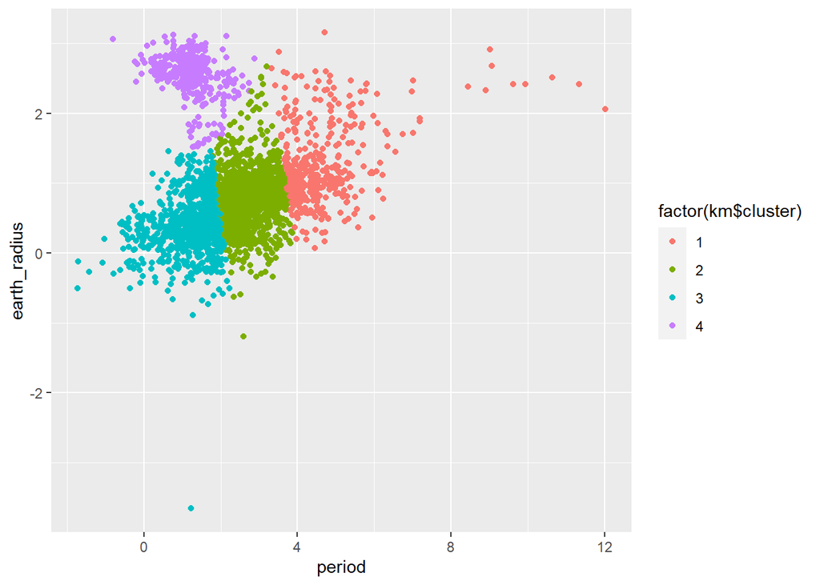

```r
ggplot(kmeans_data,aes(x=period,y=earth_radius,color = factor(km$cluster)))+geom_point()
```

##Question 7 Add the clustering labels to the dataset through a new factor column called type, with levels rocky, hot_jupiters, cold_gas_giants, others; similarly to https: //en.wikipedia.org/wiki/Exoplanet#/media/File:ExoplanetPopulations-20170616. png and produce the scatterplot highlighting these clusters

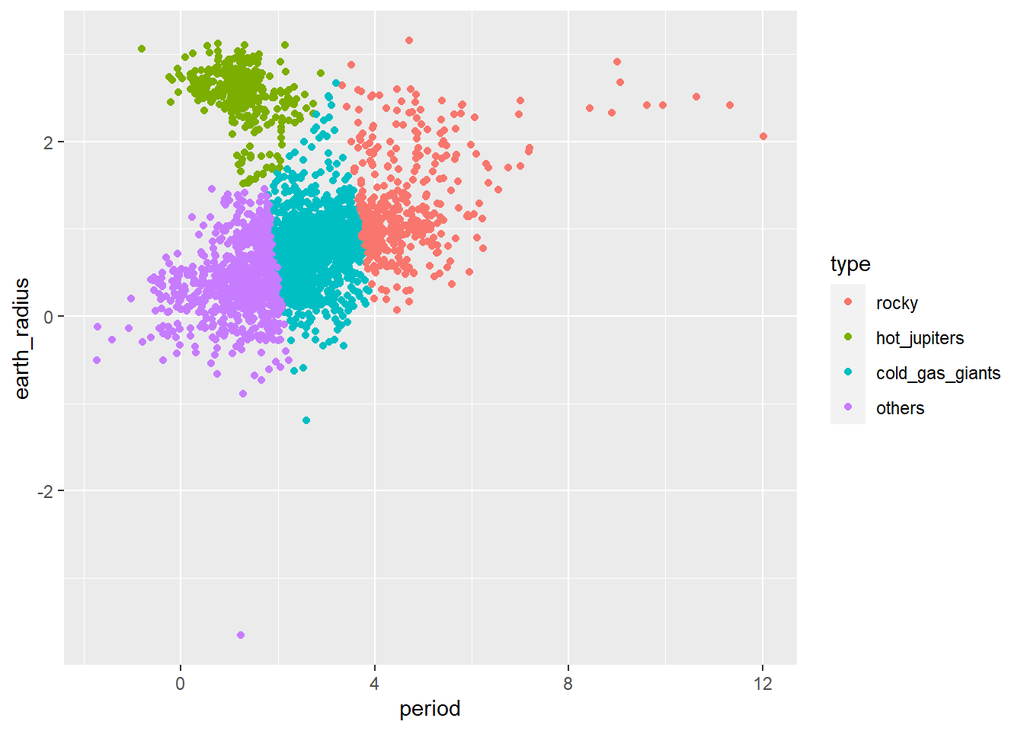

```r
exo_kmeans = exo_kmeans %>%
  mutate(type = km$cluster,
  type = case_when(
           type == 1 ~ "cold_gas_giants",
           type == 2 ~ "others",
           type == 3 ~ "Rocky",
           type == 4 ~ "hot_jupiters")%>%
           as.factor()%>%
           structure(levels=c("rocky", "hot_jupiters", "cold_gas_giants", "others")))
ggplot(exo_kmeans,aes(x=period,y=earth_radius,color = type))+geom_point()
```

##Question 8 Use a violin plot to illustrate how these clusters relate to the log-mass of the exoplanet.

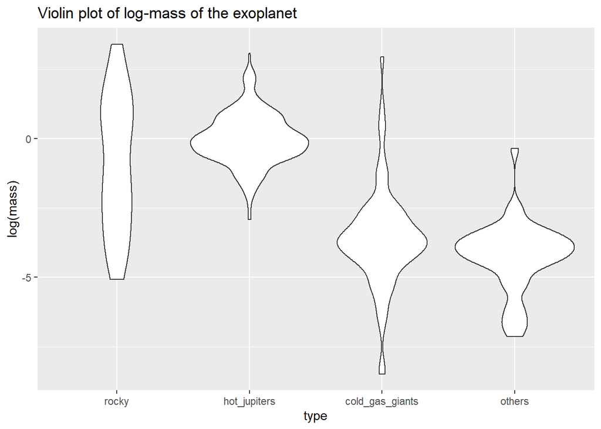

```r
ggplot(exo_kmeans, aes(x = type, y = log(mass))) +
  geom_violin() + labs(title="Violin plot of log-mass of the exoplanet")
```

##Question 9 Transform r_asc and decl into two new variables that are the same varibales but in values of seconds. Use these as coordinates to represent a celestial map for the exoplanets.

```r
# conver r_asc to seconds and save as r_asc_sec
exo$r_asc <- gsub(" ", ":", exo$r_asc, fixed=TRUE) # convert to hh:mm:ss
exo$r_asc <- hms(exo$r_asc)
exo$r_asc_sec <- period_to_seconds(exo$r_asc)
# convert Declination to seconds and save as decl_sec
exo$decl <- gsub(" ", ":", exo$decl, fixed=TRUE) # convert to dd:mm:ss, where dd=3600ss
exo$decl <- hms(exo$decl) # for Decl, dd is similar to hh where :=3600ss
```

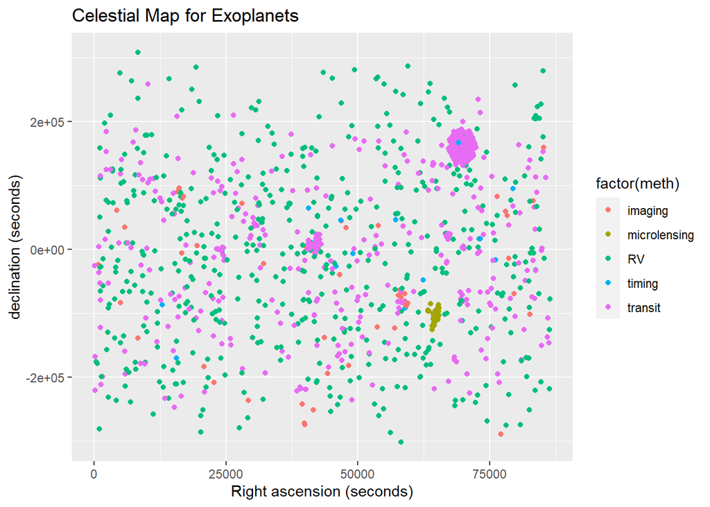

```r
exo$decl_sec <- period_to_seconds(exo$decl)

ggplot(exo, aes(r_asc_sec, decl_sec, color= factor(meth))) +
  geom_point() +
  labs(title="Celestial Map for Exoplanets", x="Right ascension (seconds)",
       y="declination (seconds)")
```

##Question 10 Create an animated time series where multiple lines illustrate the evolution over time of the total number of exoplanets discovered for each method up to that year.

```r
exo_ts <-exo %>%
           group_by(meth, year) %>%
           summarise(Count = length(meth)) %>%
           mutate(Count = cumsum(Count))
```

[figure not shown]

```r
exo_ts <-na.omit(exo_ts)
ggplot(exo_ts, aes(x = year, y = Count, group = meth)) +
      geom_line(aes(color = meth)) +
    geom_point(size = 2) +
    transition_reveal(year) +
  labs(title = 'Total number of exoplanets discovered for each method',x='year',y = 'Count')
```

##Question 12 Fit a linear regression model where log period is the response variable and the logs of host_mass, host_temp and axis are the covariates (exclude rows that contain at least one missing value). Include an intercept term in the regression model.

```r
exo_lm = exo %>%
  filter(!is.na(period))%>%
  filter(!is.na(host_mass))%>%
  filter(!is.na(host_temp))%>%
  filter(!is.na(axis))%>%
   mutate(log_period = log(period),
     log_host_mass = log(host_mass),
         log_host_temp = log(host_temp),
         log_axis = log(axis),
         na.rm = TRUE)%>%
    select(log_period,log_host_mass,log_host_temp,log_axis)

linearMod = lm(log_period~log_host_mass+log_host_temp+log_axis,data = exo_lm)
```

```r
summary(linearMod)
```

```
##
## Call:
## lm(formula = log_period ~ log_host_mass + log_host_temp + log_axis,
##     data = exo_lm)
##
## Residuals:
##     Min      1Q  Median      3Q     Max
## -2.0816 -0.0278 -0.0016  0.0277  3.4084
##
## Coefficients:
##               Estimate Std. Error t value Pr(>|t|)
## (Intercept)    5.66955    0.28995  19.554   <2e-16 ***
## log_host_mass -0.40971    0.01596 -25.679   <2e-16 ***
## log_host_temp  0.02462    0.03387   0.727    0.467
## log_axis       1.48749    0.00365 407.555   <2e-16 ***
## ---
## Signif. codes:  0 '***' 0.001 '**' 0.01 '*' 0.05 '.' 0.1 ' ' 1
##
## Residual standard error: 0.2148 on 1263 degrees of freedom
## Multiple R-squared:  0.9929, Adjusted R-squared:  0.9929
## F-statistic: 5.862e+04 on 3 and 1263 DF,  p-value: < 2.2e-16
```

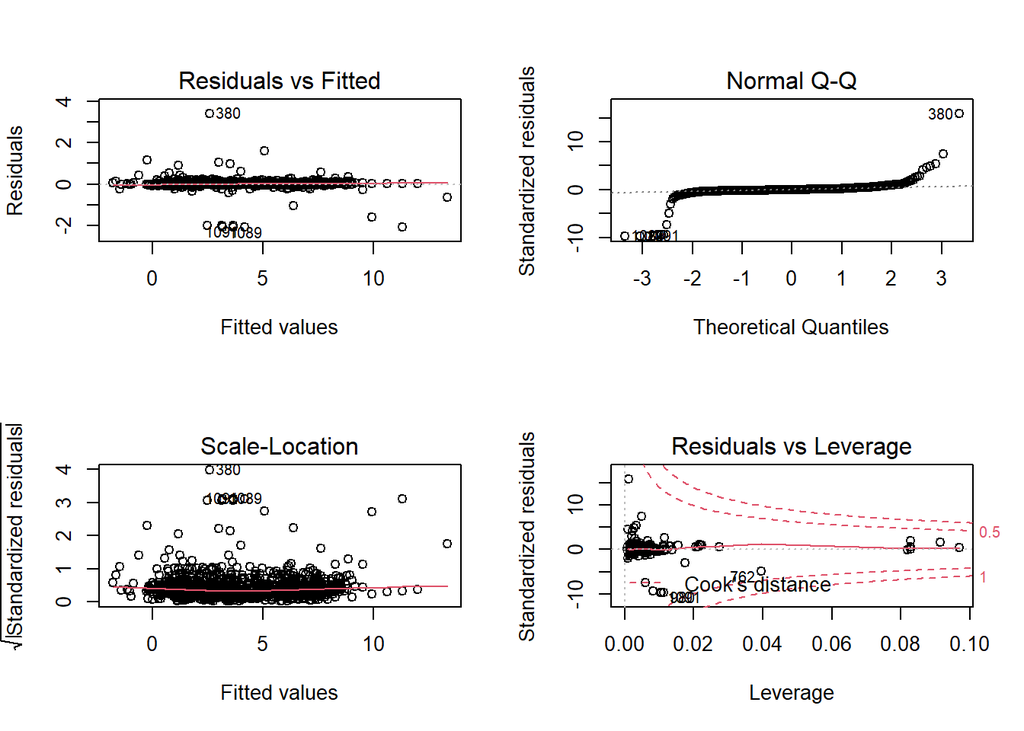

```r
par(mfrow=c(2,2)) # Change the panel layout to 2 x 2
plot(linearMod)
```